# Project: noshowappointment Dataset

- Introduction
- Data Wrangling
- Exploratory Data Analysis
- Conclusions

## Introduction

### Dataset Description

> The no show appointment dataset shows data collected information of 100k medical appointments of patients in Brazil which is centered on whether or not patients will show up for their appontment or not.

> The dataset is characterized by 14 columns
> - PatientID: Uniuqe Identification peculair to a patient
- AppointmentID: Identification of each Appoinment
- Gender: Male or Female
- ScheduledDay: The day registered for appointment
- ApointmentDay: The actual day to see the Doctor
- Age: How old the patient is
- Neighbourhood: Hospital location
- Scholarship: If the patient is enrolled for paid treatment or not
- Hipertension: If the patient has hipertension or not
- Diabetes: If the patient has Diabetes or not
- Alcoholism: If thr patient is alcoholic or not
- Handcap: If the patient has any handcap
- SMS-Received: If the patient recieves SMS for thier appointment
- No-show: if the patient showed up or not for the appointment

### Question(s) for Analysis

1. what is the percentage that showed up for their appointment?
2. Which of the gender showed up more for the appointment?
3. Can Hypertension have an effect on no-show?

```python
#Importing the required libraries
import pandas as pd
import numpy as np
import matplotlib.pyplot as plt
%matplotlib inline
import seaborn as sns
```

```python
# loading the dataset
data = pd.read_csv('noshowappointments-kagglev2-may-2016.csv')
```

```python
data.head()
```

|  | PatientId | AppointmentID | Gender | ScheduledDay | AppointmentDay | Age | Neighbourhood | Scholarship | Hipertension | Diabetes | Alcoholism | Handcap | SMS_received | No-show |
| --- | --- | --- | --- | --- | --- | --- | --- | --- | --- | --- | --- | --- | --- | --- |
| 0 | 2.987250e+13 | 5642903 | F | 2016-04-29T18:38:08Z | 2016-04-29T00:00:00Z | 62 | JARDIM DA PENHA | 0 | 1 | 0 | 0 | 0 | 0 | No |
| 1 | 5.589978e+14 | 5642503 | M | 2016-04-29T16:08:27Z | 2016-04-29T00:00:00Z | 56 | JARDIM DA PENHA | 0 | 0 | 0 | 0 | 0 | 0 | No |
| 2 | 4.262962e+12 | 5642549 | F | 2016-04-29T16:19:04Z | 2016-04-29T00:00:00Z | 62 | MATA DA PRAIA | 0 | 0 | 0 | 0 | 0 | 0 | No |
| 3 | 8.679512e+11 | 5642828 | F | 2016-04-29T17:29:31Z | 2016-04-29T00:00:00Z | 8 | PONTAL DE CAMBURI | 0 | 0 | 0 | 0 | 0 | 0 | No |
| 4 | 8.841186e+12 | 5642494 | F | 2016-04-29T16:07:23Z | 2016-04-29T00:00:00Z | 56 | JARDIM DA PENHA | 0 | 1 | 1 | 0 | 0 | 0 | No |

```python
#Number of rows and columns in the dataset
data.shape
```

```
(110527, 14)
```

```python
#Information of every column in the dataset
data.info()
```

```
<class 'pandas.core.frame.DataFrame'>
RangeIndex: 110527 entries, 0 to 110526
Data columns (total 14 columns):
 #   Column          Non-Null Count   Dtype
---  ------          --------------   -----
 0   PatientId       110527 non-null  float64
 1   AppointmentID   110527 non-null  int64
 2   Gender          110527 non-null  object
 3   ScheduledDay    110527 non-null  object
 4   AppointmentDay  110527 non-null  object
 5   Age             110527 non-null  int64
 6   Neighbourhood   110527 non-null  object
 7   Scholarship     110527 non-null  int64
 8   Hipertension    110527 non-null  int64
 9   Diabetes        110527 non-null  int64
 10  Alcoholism      110527 non-null  int64
 11  Handcap         110527 non-null  int64
 12  SMS_received    110527 non-null  int64
 13  No-show         110527 non-null  object
dtypes: float64(1), int64(8), object(5)
memory usage: 11.8+ MB
```

```python
#Description for the dataset(all columns)
data.describe()
```

|  | PatientId | AppointmentID | Age | Scholarship | Hipertension | Diabetes | Alcoholism | Handcap | SMS_received |
| --- | --- | --- | --- | --- | --- | --- | --- | --- | --- |
| count | 1.105270e+05 | 1.105270e+05 | 110527.000000 | 110527.000000 | 110527.000000 | 110527.000000 | 110527.000000 | 110527.000000 | 110527.000000 |
| mean | 1.474963e+14 | 5.675305e+06 | 37.088874 | 0.098266 | 0.197246 | 0.071865 | 0.030400 | 0.022248 | 0.321026 |
| std | 2.560949e+14 | 7.129575e+04 | 23.110205 | 0.297675 | 0.397921 | 0.258265 | 0.171686 | 0.161543 | 0.466873 |
| min | 3.921784e+04 | 5.030230e+06 | -1.000000 | 0.000000 | 0.000000 | 0.000000 | 0.000000 | 0.000000 | 0.000000 |
| 25% | 4.172614e+12 | 5.640286e+06 | 18.000000 | 0.000000 | 0.000000 | 0.000000 | 0.000000 | 0.000000 | 0.000000 |
| 50% | 3.173184e+13 | 5.680573e+06 | 37.000000 | 0.000000 | 0.000000 | 0.000000 | 0.000000 | 0.000000 | 0.000000 |
| 75% | 9.439172e+13 | 5.725524e+06 | 55.000000 | 0.000000 | 0.000000 | 0.000000 | 0.000000 | 0.000000 | 1.000000 |
| max | 9.999816e+14 | 5.790484e+06 | 115.000000 | 1.000000 | 1.000000 | 1.000000 | 1.000000 | 4.000000 | 1.000000 |

```python
#Data type information
data.dtypes
```

```
PatientId         float64
AppointmentID       int64
Gender             object
ScheduledDay       object
AppointmentDay     object
Age                 int64
Neighbourhood      object
Scholarship         int64
Hipertension        int64
Diabetes            int64
Alcoholism          int64
Handcap             int64
SMS_received        int64
No-show            object
dtype: object
```

After checking the general properties of the dataset, I observed that there are 110527 rows and 14 columns. Also, there are no missing values and duplicate rows. But looking at the summary statistics of age, I observed that the minimum age is negative which should not be so.

### Data Cleaning

```python
#Checking the dimension of the dataset
data.columns
```

```
Index(['PatientId', 'AppointmentID', 'Gender', 'ScheduledDay',
       'AppointmentDay', 'Age', 'Neighbourhood', 'Scholarship', 'Hipertension',
       'Diabetes', 'Alcoholism', 'Handcap', 'SMS_received', 'No-show'],
      dtype='object')
```

```python
#Checking for missing values
data.isnull().sum()
```

```
PatientId         0
AppointmentID     0
Gender            0
ScheduledDay      0
AppointmentDay    0
Age               0
Neighbourhood     0
Scholarship       0
Hipertension      0
Diabetes          0
Alcoholism        0
Handcap           0
SMS_received      0
No-show           0
dtype: int64
```

```python
#Check for all the unique features in the dataset
data.nunique()
```

```
PatientId          62299
AppointmentID     110527
Gender                 2
ScheduledDay      103549
AppointmentDay        27
Age                  104
Neighbourhood         81
Scholarship            2
Hipertension           2
Diabetes               2
Alcoholism             2
Handcap                5
SMS_received           2
No-show                2
dtype: int64
```

```python
#Check for duplicate values
sum(data.duplicated())
```

```
0
```

```python
#The dataset shows that both ScheduledDay and AppointmentDay are not in correct types.
#Convert to datetime types to get month and date.
data['ScheduledDay'] = pd.to_datetime(data['ScheduledDay'])
data['AppointmentDay'] = pd.to_datetime(data['AppointmentDay'])
```

```python
data.info()
```

```
<class 'pandas.core.frame.DataFrame'>
RangeIndex: 110527 entries, 0 to 110526
Data columns (total 14 columns):
 #   Column          Non-Null Count   Dtype
---  ------          --------------   -----
 0   PatientId       110527 non-null  float64
 1   AppointmentID   110527 non-null  int64
 2   Gender          110527 non-null  object
 3   ScheduledDay    110527 non-null  datetime64[ns, UTC]
 4   AppointmentDay  110527 non-null  datetime64[ns, UTC]
 5   Age             110527 non-null  int64
 6   Neighbourhood   110527 non-null  object
 7   Scholarship     110527 non-null  int64
 8   Hipertension    110527 non-null  int64
 9   Diabetes        110527 non-null  int64
 10  Alcoholism      110527 non-null  int64
 11  Handcap         110527 non-null  int64
 12  SMS_received    110527 non-null  int64
 13  No-show         110527 non-null  object
dtypes: datetime64[ns, UTC](2), float64(1), int64(8), object(3)
memory usage: 11.8+ MB
```

```python
#Checking the counts for the No_show column
data['No-show'].value_counts()
```

```
No     88208
Yes    22319
Name: No-show, dtype: int64
```

```python
data['Age'].value_counts()
```

```
 0      3539
 1      2273
 52     1746
 49     1652
 53     1651
        ...
 115       5
 100       4
 102       2
 99        1
-1         1
Name: Age, Length: 104, dtype: int64
```

```python
# There is an outlier of -1 found in the Age column
# Drop the outlier
data.drop(data.query('Age ==1').index, inplace=True)
```

```python
data.rename(columns ={'No-show':'No_show'}, inplace = True )
```

```python
data.Handcap.value_counts()
```

```
0    106014
1      2041
2       183
3        13
4         3
Name: Handcap, dtype: int64
```

```python
data.Hipertension.value_counts()
```

```
0    86453
1    21801
Name: Hipertension, dtype: int64
```

```python
data.Diabetes.value_counts()
```

```
0    100312
1      7942
Name: Diabetes, dtype: int64
```

```python
data.Alcoholism.value_counts()
```

```
0    104894
1      3360
Name: Alcoholism, dtype: int64
```

```python
data.Scholarship.value_counts()
```

```
0    97475
1    10779
Name: Scholarship, dtype: int64
```

```python
data.No_show.value_counts()
```

```
No     86350
Yes    21904
Name: No_show, dtype: int64
```

```python
data['SMS_received'].value_counts()
```

```
0    73338
1    34916
Name: SMS_received, dtype: int64
```

## Exploratory Data Analysis

```
array([[<AxesSubplot:title={'center':'PatientId'}>,
        <AxesSubplot:title={'center':'AppointmentID'}>,
        <AxesSubplot:title={'center':'ScheduledDay'}>],
       [<AxesSubplot:title={'center':'AppointmentDay'}>,
        <AxesSubplot:title={'center':'Age'}>,
        <AxesSubplot:title={'center':'Scholarship'}>],
       [<AxesSubplot:title={'center':'Hipertension'}>,
        <AxesSubplot:title={'center':'Diabetes'}>,
        <AxesSubplot:title={'center':'Alcoholism'}>],
       [<AxesSubplot:title={'center':'Handcap'}>,
        <AxesSubplot:title={'center':'SMS_received'}>, <AxesSubplot:>]],
      dtype=object)
```

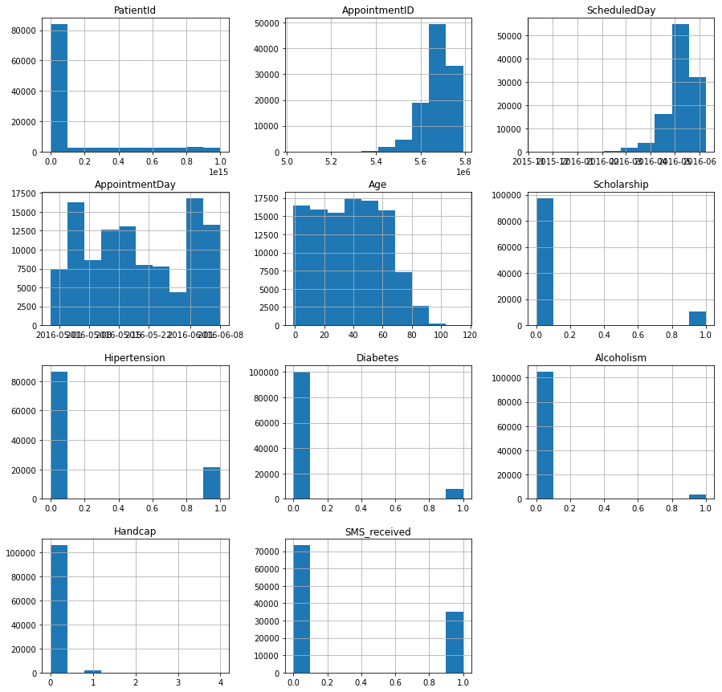

```python
# Using hist() function to get histogram analysis for all the columns that have numerical values
data.hist(figsize=(15,15), alpha=1)
```

To find out the percentage of each features

```python
# Using a plot pie function,analyze the selected columns for visuals
def pie_plot(x):
    have = ['No','Yes']
    data[x].value_counts().plot.pie(labels=have,autopct='%1.0f%%');
```

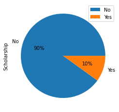

```python
pie_plot('Scholarship')
plt.legend();
```

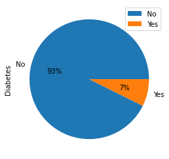

```python
pie_plot('Diabetes')
plt.legend();
```

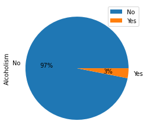

```python
pie_plot('Alcoholism')
plt.legend();
```

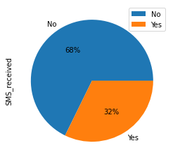

```python
pie_plot('SMS_received')
plt.legend();
```

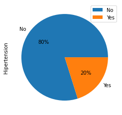

```python
pie_plot('Hipertension')
plt.legend();
```

For columns 'Scholarship', 'alcoholism', 'diabetes', 'sms_received' and hipertension .. all of them were evaluated as Yes and No. So, we can fairly say:

10% of all records does have scholarships,

7% of all records have diabets,

3% of all records are alcoholic,

32% did recieve an sms and,

20% of all records with hipertension.

## Research Question 1(what is the percentage that showed up for their appointment?)

```python
#Convert No-show column containing 'yes' and 'no' with 1 and 0
# to convert from Str to int
data['No_show'].replace(('No','Yes'),(1, 0), inplace=True)
```

```python
float(data['No_show'].value_counts()[0]/len(data)*100)
```

```
20.23389435956177
```

```python
float(data['No_show'].value_counts()[1]/len(data)*100)
```

```
79.76610564043824
```

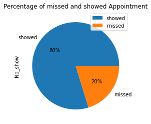

```python
#Ratio between those that showed and those that missed appointment
data["No_show"].value_counts().plot.pie(labels = ['showed','missed'], autopct = '%1.0f%%');
plt.title('Percentage of missed and showed Appointment')
plt.legend();
```

From the piechart above, we can see that 20% of the scheduled appointment were not attended by patients.